# Rmark

Raghav Khanal, Srihari Govind, Rachael Barrett, Mahim Eaty, Oumnia Bouaddi

2026-09-07

This R Markdown file contains the data analysis for the scoping review titled “Health Outcomes and Challenges among Youth and Children on the Move in the Context of Climate Change–Related Migration.” The review protocol is publicly registered on the Open Science Framework (OSF): https://doi.org/10.17605/OSF.IO/PJKNC.

All data, analysis files, and supporting materials are also publicly available in our GitHub repository (https://github.com/ragathefreeman/MYCP) to promote open science, transparency, and reproducible research practices.

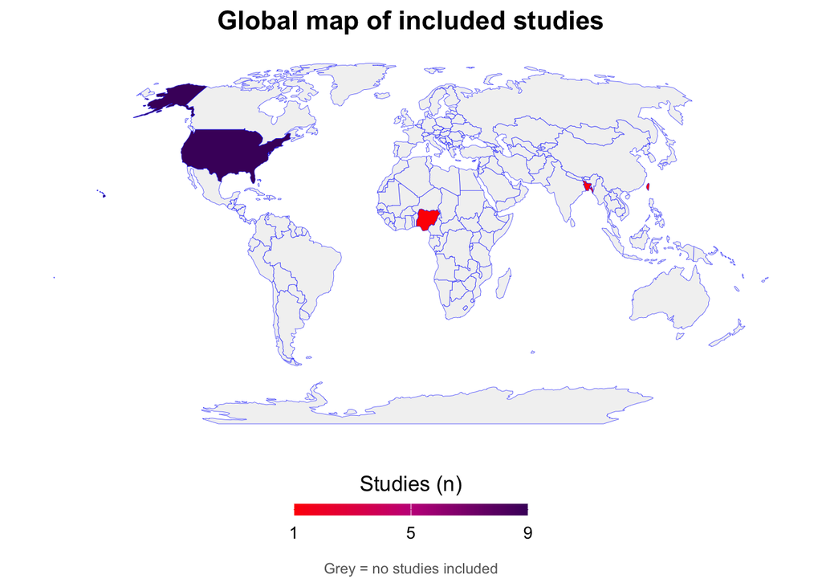

```r
library(readxl)
library(tidyverse)
library(countrycode)
library(rnaturalearth)
library(sf)
library(RColorBrewer)
library(gtsummary)
library(gt)

# Import data (name of data is analysis.xlsx)
d11 <- read_excel("dataextraction/analysis.xlsx")
# Convert variables to factors
d11$`Country-Economy`<-as.factor(d11$`Country-Economy`)
d11$Gender <- as.factor(d11$Gender)
d11$`Socio-economic` <- as.factor(d11$`Socio-economic`)
d11$`Socio-behavioral` <- as.factor(d11$`Socio-behavioral`)
d11$Demographic <- as.factor(d11$Demographic)
d11$Biological <- as.factor(d11$Biological)
d11$Geographic <- as.factor(d11$Geographic)
d11$`Health System Capacity` <- as.factor(d11$`Health System Capacity`)

# Geographic distribution
country_counts <- as.data.frame(table(d11$Country))
names(country_counts) <- c("Country", "n")

country_counts$iso_a3 <- countrycode(
  country_counts$Country,
  origin = "country.name",
  destination = "iso3c"
)

world <- ne_countries(
  scale = "small",
  returnclass = "sf"
)

world_joined <- world %>%
  left_join(country_counts, by = "iso_a3")

ggplot(world_joined) +
  geom_sf(aes(fill = n), color = "blue", size = 0.1) +
scale_fill_gradientn(
  colors = c("red", "#c51b8a", "#49006a"),
  na.value = "grey95",
  name = "Studies (n)",
  breaks = c(1,5,9),
  limits = c(1, max(country_counts$n, na.rm = TRUE)),
  guide = guide_colorbar(
    barwidth = 10, barheight = 0.5,
    title.position = "top", title.hjust = 0.5
  )
) +
  coord_sf(crs = "+proj=robin") +   # Robinson projection — less distorted than default
  labs(
    title = "Global map of included studies",
    caption = "Grey = no studies included"
  ) +
  theme_minimal(base_size = 13) +
  theme(
    plot.title = element_text(hjust = 0.5, face = "bold", size = 16),
    plot.caption = element_text(hjust = 0.5, size = 9, color = "grey40"),
    axis.text = element_blank(),
    axis.title = element_blank(),
    axis.ticks = element_blank(),
    panel.grid = element_blank(),
    legend.position = "bottom"
  )
```

```r
ggsave("~/Desktop/SSH/MYCP/Images/map.jpg")
```

Among 12 included studies, 9 were from United States of America (USA), and 1 from Bangladesh, 1 Nigeria and 1 Taiwan.

```r
ggsave(
  "~/Desktop/SSH/MYCP/Images/country_map.png",
  width = 10,
  height = 6,
  dpi = 500
)
rawtable <- table(
  d11$`Country-Economy`
)

Incomepercentage <- prop.table(rawtable) * 100

print(Incomepercentage)
```

```
##
##      HIC     LMIC
## 83.33333 16.66667
```